# p8106_midterm_project

David DeStephano

March 27, 2020

# Introduction

Hosptial billing is often nebulous, and differs dramatically from actual costs. The purpose of this project is to use SPARCS deidentified data to predict total charges of service for newborns in NYS. We hope to achieve a model that performs relatively well on the majority of observations, and performs reasonably well on high outliers, of which there are many. We also hope to determine if demographic and insurance characteristics are influential on charges (not costs of service), to see if patient and payer characteristics affect hospital inpatient charges.

Data was downloaded from the NYS health data website: https://health.data.ny.gov/Health/Hospital-Inpatient-Discharges-SPARCS-De-Identified/npsr-cm47

The data was cleaned by reoving any observation without a missing birthweight variable, to limit the analysis to newborns only. The data had variables for diagnosis and procedure codes as well as descriptions, so redundant variables were removed. Descriptions were kept as to aid with interpretation.

Variables with too many categories such as zip code and hospital name were removed. The remainder of categorical variables were then dummified to ensure the variables would work well with Caret. To avoid multicolinearity the option fullRank=T was used in the dummyVar function.

Due to the high amount of categories in some of these variables, categories with zero or near zero variances were examined. They were then determined to not improve model performance significantly, and were removed in subsequent models. The variables removed were CCS diagnosis and procedure codes, as well as the APR DRG variable. This left the model with multilevel (CCS) variables, while single level variables were removed.

# Exploratory Analysis

As expected, charges vastly surpass the actual costs of inpatient stays for newborns. There appear to be slight differences in slopes between cost and charges for different races, but this can not be tested to be meaningful at this stage. There also appear to be differences between payment type intercepts, meaning that demographic and payment typology may interact with costs/charges or may not be uniform between groups.

# Models

Many variables were dropped for the final model, none of which significantly increased model performance. The final model containted the following predictors:

[1] “apr_mdc_description”  
[2] “apr_medical_surgical_description”  
[3] “apr_risk_of_mortality”  
[4] “apr_severity_of_illness_description” [5] “birth_weight”  
[6] “emergency_department_indicator”  
[7] “ethnicity”  
[8] “gender”  
[9] “health_service_area”  
[10] “hospital_county”  
[11] “length_of_stay”  
[12] “patient_disposition”  
[13] “payment_typology_1”  
[14] “race”  
[15] “total_costs”  
[16] “type_of_admission”

A linear model and PCR were fit initially to test the performance when including APR DRG, and CCS variables. These variables were removed, and a linear model, PCR, lasso, and elastic net were used on the dummified dataset. Tuning parameters were choses using 5 fold cross validation A GAM model was fit as well to account for possible non linearity.

Obviously cost was important in predicting total charges, but the other continuous variables were also important, including length of stay and birthweight. Risk of mortality and severity were also important predictors.

Limitations include extreme outlying charges. Tese observations resuted in high errors, as they were much more difficult to accurately predict. The models also did not include interaction terms, so there was no test of whether there is an interaction between cost and race or payment typology.

# Conclusion

# Data Analysis

## Load the data set

Tips for dealing with large data https://rpubs.com/msundar/large_data_analysis

```r
library(tidyverse)
library(caret)
library(summarytools)
```

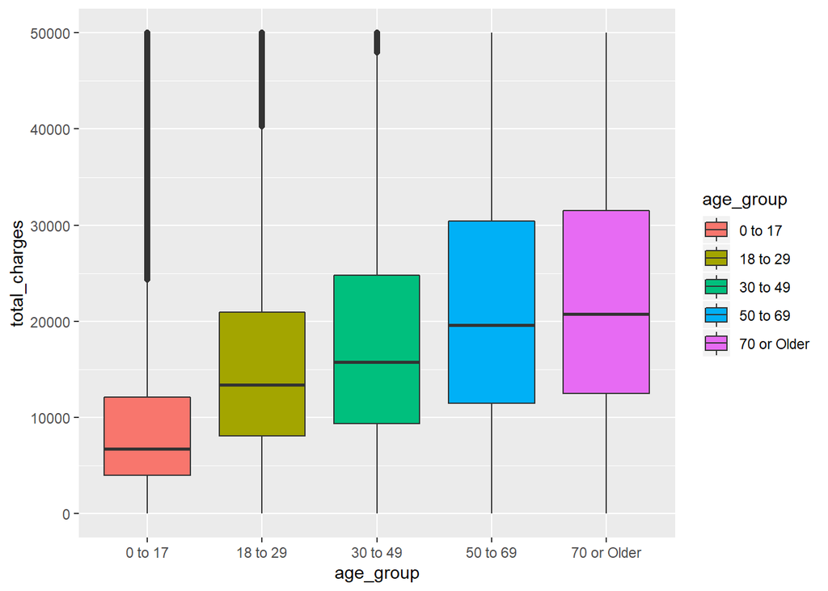

```r
library(cowplot)
library(ModelMetrics)
library(pls)
sparcs<-read_csv("Hospital_Inpatient_Discharges__SPARCS_De-Identified___2013.csv")
sparcs %>% janitor::clean_names() %>%  ggplot(aes(x = age_group, y=total_charges, fill = age_group))+
  geom_boxplot() +ylim(0,50000)
```

## 2,000,000 rows is excessive, and I do not want to wait forever when running models. So I am just going to look at newborns and see if we can predict costs

```r
newborns<-sparcs %>% filter(`Birth Weight`!="0000") %>% janitor::clean_names()
rm(sparcs)
```

## Descriptive Stats and Visualization

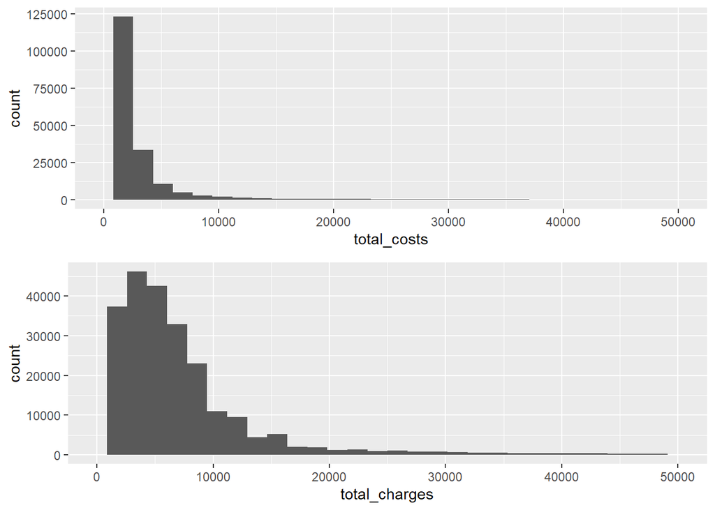

```r
a<-newborns %>% ggplot(aes(x=total_costs))+
  geom_histogram()+xlim(0,50000)

b<-newborns %>% ggplot(aes(x=total_charges))+
  geom_histogram()+xlim(0,50000)

require(gridExtra)
grid.arrange(a,b)
```

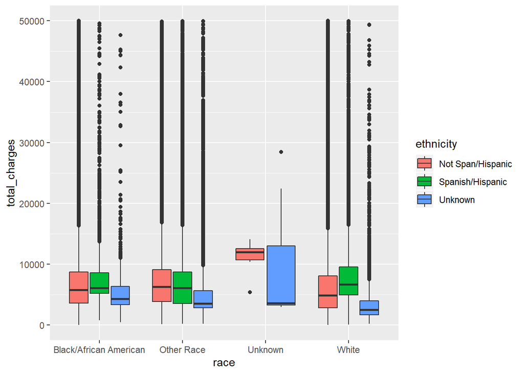

```r
# ggplot(newborns, aes(x = total_charges, y = ..density..)) +
#     stat_density(geom="line")  +xlim(0,50000)



newborns %>% ggplot(aes(x = race, y=total_charges, fill = ethnicity))+
  geom_boxplot() +ylim(0,50000)
```

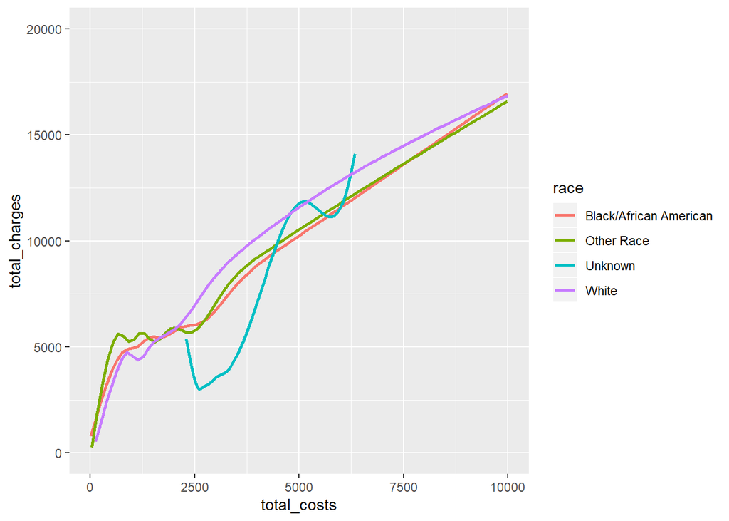

```r
newborns %>%
  ggplot(aes(x = total_costs, y=total_charges, group=race, color=race))+
  geom_smooth(se=FALSE)+ylim(0,20000) + xlim(0, 10000)
```

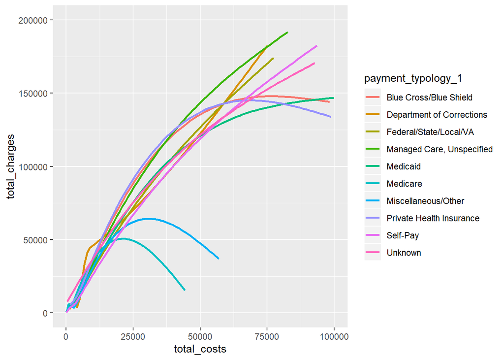

```r
newborns  %>%
  ggplot(aes(x = total_costs, y=total_charges, group=payment_typology_1, color=payment_typology_1))+
  geom_smooth(se=FALSE)+ylim(0,200000) + xlim(0, 100000)
```

# Remove redundant categorical variables, dummify the remaining categorical variables, and remove zero variance predictors

```r
newborn_model<-newborns %>% select(-operating_certificate_number, -facility_id, -discharge_year, -age_group, -ccs_diagnosis_code, -ccs_procedure_code, -apr_drg_code, -apr_mdc_code, -apr_severity_of_illness_code, -payment_typology_2, -payment_typology_3, -abortion_edit_indicator) %>%
  mutate(birth_weight=as.numeric(birth_weight),
         length_of_stay=as.numeric(length_of_stay)) %>%
  na.omit() #Don't feel like imputing

#A lot of categorical variables:
#facility_name
#zip code
#remove apr_drg_description?

newborn_model <- newborn_model %>% select(-facility_name, -zip_code_3_digits)

dmy<- dummyVars(" ~.", data=newborn_model, fullRank = T)
trsf <- data.frame(predict(dmy, newdata = newborn_model))

#zero_var = nearZeroVar(trsf, saveMetrics = TRUE)
#23821.100
```

There are many near zero variance dummy variables. There were several ideas on how to deal with this: could remove any dummy variable with less than ten observations using nearZeroVar(), as they have very low variance, this will help speed up the model.. This could severley affect the reference as there are many cost outliers.. So under normal circumstances this would not be ideal… Should maybe just delete the patients with these variables? Or could just rerun the analysis later and exclude ccs_procedure ccs_diagnosis apr_drg variables (the variables with the most dummies) and compare the RMSE. Will try this after running a linear model and PCR, with 3 fold CV, as to save computing power on the 500 variable dataset.

# Create test and training data

```r
set.seed(1)
rowTrain <-createDataPartition(y = trsf$total_charges,
                               p = 2/3,
                               list = FALSE)

# training data
x <- model.matrix(total_charges~.,trsf)[rowTrain,-1]
y <- trsf$total_charges[rowTrain]

# test data
x2 <- model.matrix(total_charges~.,trsf)[-rowTrain,-1]
y2 <- trsf$total_charges[-rowTrain]
```

# Linear model using CCS and APR DRG categories

## Commented out due to computation time

```r
# ctrl1 <-trainControl(method = "cv", number = 3)
# set.seed(1)
#
# lm.fit <-train(x, y, method = "lm",trControl = ctrl1)
#
# predy2.lm <-predict(lm.fit, newdata = x2)
#
# mae(y2, predy2.lm)
# mse(y2, predy2.lm)
# rmse(y2, predy2.lm)
```

By comparison, here are the estimates if you were to model cost instead of charges: MAE: [1] 1863.642 MSE [1] 43849131 RMSE [1] 6621.868 Obviously charges can vary more wildly

# PCR using CCS and APR DRG variables

```r
# set.seed(1)
# pcr.fit <- train(x, y,
#                  method = "pcr",
#                  tuneGrid = data.frame(ncomp = 1:425),
#                  trControl = ctrl1,
#                  preProc = c("center", "scale"))
#
# predy2.pcr4 <- predict(pcr.fit, newdata = x2)
#
# mae(y2, predy2.pcr4)
# mse(y2, predy2.pcr4)
# rmse(y2, predy2.pcr4)
#
# ggplot(pcr.fit, highlight = TRUE) + theme_bw()
# pcr.fit$bestTune
#
# pcr.fit$results %>% filter(ncomp==397)
```

On seperate test data: MAE: [1] 8055.074 MSE: [1] 840093694 RMSE: [1] 28984.37

# Try the analysis again without the ccs_procedure, ccs_diagnosis, and apr_drg variables

## Choice to try this method and compare instead of either dropping dummy variables with low freqs or dropping patients with those categories

```r
newborn_model2 <- newborn_model %>% select(-ccs_diagnosis_description, -ccs_procedure_description, -apr_drg_description)

dmy2<- dummyVars(" ~.", data=newborn_model2, fullRank = T)
trsf2 <- data.frame(predict(dmy2, newdata = newborn_model2))
```

```r
set.seed(1)
rowTrain <-createDataPartition(y = trsf2$total_charges,
                               p = 2/3,
                               list = FALSE)

# training data
x <- model.matrix(total_charges~.,trsf2)[rowTrain,-1]
y <- trsf$total_charges[rowTrain]

# test data
x2 <- model.matrix(total_charges~.,trsf2)[-rowTrain,-1]
y2 <- trsf$total_charges[-rowTrain]
```

# Linear model

```r
ctrl1 <-trainControl(method = "cv", number = 5)
#ctrl1 <-trainControl(method = "none")
set.seed(1)

lm.fit2 <-train(x, y, method = "lm",trControl = ctrl1)
predy2.lm2 <-predict(lm.fit2, newdata = x2)
mae(y2, predy2.lm2)
```

```
## [1] 7607.35
```

```r
mse(y2, predy2.lm2)
```

```
## [1] 759475780
```

```r
rmse(y2, predy2.lm2)
```

```
## [1] 27558.59
```

Very similar RMSE to before.

# PCR

```r
set.seed(1)
pcr.fit2 <- train(x, y,
                 method = "pcr",
                 tuneGrid = data.frame(ncomp = 1:118),
                 trControl = ctrl1,
                 preProc = c("center", "scale"))
pred.pcr2 <- predict(pcr.fit2, newdata = x2)

mae(y2, pred.pcr2)
```

```
## [1] 7605.597
```

```r
mse(y2, pred.pcr2)
```

```
## [1] 759435090
```

```r
rmse(y2, pred.pcr2)
```

```
## [1] 27557.85
```

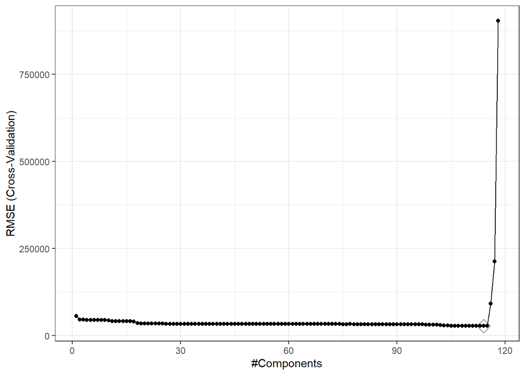

```r
ggplot(pcr.fit2, highlight = TRUE) + theme_bw()
```

```r
pcr.fit2$bestTune
```

```
##     ncomp
## 114   114
```

```r
pcr.fit2$results %>% filter(ncomp==114)
```

```
##   ncomp     RMSE  Rsquared      MAE   RMSESD  RsquaredSD    MAESD
## 1   114 27173.47 0.8350327 7561.453 901.1576 0.004526508 113.6783
```

Removing the CCS and APR variables provides a lower RMSE and MAE compared to the previous model with these variables included. I think computationally this model is a better choice, and we have evidence that it actually performs better. We only lose 0.2% from our Rsquared value.

This tells us that perhaps the super-specific diagnosis and procedure codes are not highly predicitve of charges, this somewhat defies expectations, as billing is generally completed using billing codes. This could just be the case for infants, as length of stay and severity are probably much greater factors of charges, while procedures are disproportionately and more or less uniformly deliveries, with some complications explainig the higher charges.

```r
importance = varImp(pcr.fit2, scale=FALSE)
importance
```

```
## loess r-squared variable importance
##
##   only 20 most important variables shown (out of 124)
##
##                                                                      Overall
## total_costs                                                         0.789721
## length_of_stay                                                      0.770978
## apr_risk_of_mortalityMinor                                          0.238951
## apr_risk_of_mortalityMajor                                          0.156059
## birth_weight                                                        0.138973
## apr_medical_surgical_descriptionSurgical                            0.101646
## apr_risk_of_mortalityModerate                                       0.071746
## apr_severity_of_illness_descriptionMinor                            0.069706
## patient_dispositionHome.or.Self.Care                                0.061539
## patient_dispositionHome.w..Home.Health.Services                     0.042714
## apr_severity_of_illness_descriptionMajor                            0.040295
## patient_dispositionCancer.Center.or.Children.s.Hospital             0.025643
## type_of_admissionUrgent                                             0.009706
## type_of_admissionNewborn                                            0.008201
## patient_dispositionSkilled.Nursing.Home                             0.005171
## patient_dispositionShort.term.Hospital                              0.003954
## patient_dispositionExpired                                          0.003867
## apr_mdc_descriptionDiseases.and.Disorders.of.the.Circulatory.System 0.002868
## hospital_countyManhattan                                            0.002457
## health_service_areaNew.York.City                                    0.001940
```

We only needed 114 components this time, which is still not great so will try alternative models.

# Lasso

```r
set.seed(1)
lasso.fit <- train(x, y,
                   method = "glmnet",
                   tuneGrid = expand.grid(alpha = 1,
                                          lambda = exp(seq(-1, 5, length=100))),
                   preProc = c("center", "scale"),
trControl = ctrl1)
```

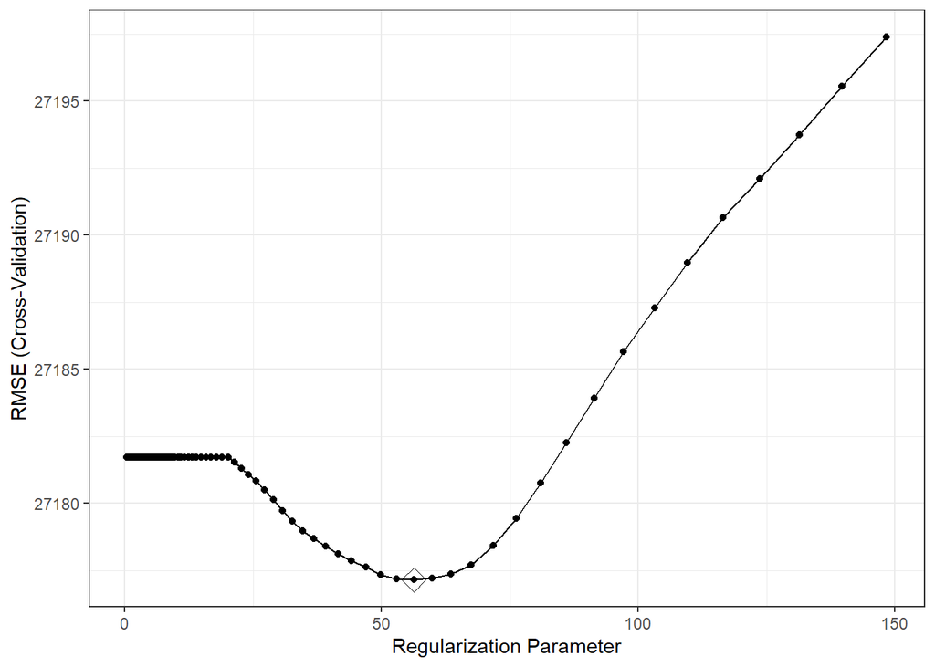

```r
ggplot(lasso.fit, highlight = TRUE) + theme_bw()
```

```r
lasso.fit$bestTune
```

```
##    alpha   lambda
## 84     1 56.27796
```

```r
coef(lasso.fit$finalModel,lasso.fit$bestTune$lambda)
```

```
## 125 x 1 sparse Matrix of class "dgCMatrix"
##                                                                                                                                     1
## (Intercept)                                                                                                             16898.1837108
## health_service_areaCentral.NY                                                                                            -412.6673752
## health_service_areaFinger.Lakes                                                                                           -36.5002735
## health_service_areaHudson.Valley                                                                                            .
## health_service_areaLong.Island                                                                                            591.0723618
## health_service_areaNew.York.City                                                                                            .
## health_service_areaSouthern.Tier                                                                                         -258.0518045
## health_service_areaWestern.NY                                                                                            -793.5381855
## hospital_countyAllegany                                                                                                     .
## hospital_countyBronx                                                                                                      299.1984344
## hospital_countyBroome                                                                                                    -371.6393346
## hospital_countyCattaraugus                                                                                               -138.0186509
## hospital_countyCayuga                                                                                                       .
## hospital_countyChautauqua                                                                                                -181.5364801
## hospital_countyChemung                                                                                                   -663.8074253
## hospital_countyChenango                                                                                                     .
## hospital_countyClinton                                                                                                    -94.0157144
## hospital_countyColumbia                                                                                                     .
## hospital_countyCortland                                                                                                     .
## hospital_countyDutchess                                                                                                  -236.7208145
## hospital_countyErie                                                                                                         .
## hospital_countyFranklin                                                                                                   -24.1437417
## hospital_countyFulton                                                                                                      -2.9631000
## hospital_countyGenesee                                                                                                     90.8797965
## hospital_countyJefferson                                                                                                    .
## hospital_countyKings                                                                                                     -207.7970154
## hospital_countyLewis                                                                                                        .
## hospital_countyLivingston                                                                                                   0.9692651
## hospital_countyMadison                                                                                                    -13.8801236
## hospital_countyManhattan                                                                                                  884.9872860
## hospital_countyMonroe                                                                                                   -1315.8199862
## hospital_countyMontgomery                                                                                                 -36.5510547
## hospital_countyNassau                                                                                                     467.6712257
## hospital_countyNiagara                                                                                                      .
## hospital_countyOneida                                                                                                     -40.9174359
## hospital_countyOnondaga                                                                                                 -1029.6415099
## hospital_countyOntario                                                                                                      .
## hospital_countyOrange                                                                                                      56.5976768
```

[output cut: 72 more lines]

```
## apr_risk_of_mortalityMinor                                                                                              -4383.0472602
## apr_risk_of_mortalityModerate                                                                                           -3512.2878542
## apr_medical_surgical_descriptionSurgical                                                                                 4298.6760365
## payment_typology_1Department.of.Corrections                                                                               -85.4177210
## payment_typology_1Federal.State.Local.VA                                                                                  -53.9186299
## payment_typology_1Managed.Care..Unspecified                                                                                 .
## payment_typology_1Medicaid                                                                                               -695.9199655
## payment_typology_1Medicare                                                                                                -25.9515239
## payment_typology_1Miscellaneous.Other                                                                                    -219.9217621
## payment_typology_1Private.Health.Insurance                                                                                 91.1103347
## payment_typology_1Self.Pay                                                                                               -228.4657796
## payment_typology_1Unknown                                                                                                -103.6002499
## birth_weight                                                                                                              515.8188446
## emergency_department_indicatorY                                                                                          -299.8110364
## total_costs                                                                                                             30990.9346108
```

I could not tell you why the coefficient estimate is 30000 for cost, is this for every dollar of cost? Or did something happen with the standardization process?

# Enet

```r
set.seed(1)
enet.fit <- train(x, y,
                  method = "glmnet",
                  tuneGrid = expand.grid(alpha = seq(0, 1, length = 5),
                                         lambda = exp(seq(-2, 6, length = 50))),
                  preProc = c("center", "scale"),
                  trControl = ctrl1)
pred.enet <- predict(enet.fit, newdata = x2)

mae(y2, pred.enet)
```

```
## [1] 7486.917
```

```r
mse(y2, pred.enet)
```

```
## [1] 760201905
```

```r
rmse(y2, pred.enet)
```

```
## [1] 27571.76
```

```r
#enet.fit$results
```

```r
enet.fit$bestTune
```

```
##     alpha   lambda
## 238     1 56.87275
```

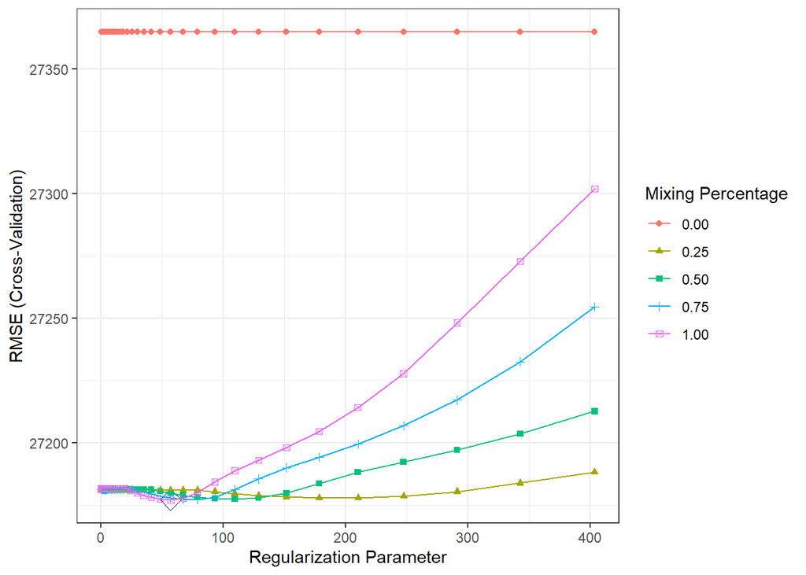

```r
ggplot(enet.fit, highlight = TRUE) + theme_bw()
```

```r
coef(enet.fit$finalModel,enet.fit$bestTune$lambda)
```

```
## 125 x 1 sparse Matrix of class "dgCMatrix"
##                                                                                                                                    1
## (Intercept)                                                                                                             16898.183711
## health_service_areaCentral.NY                                                                                            -414.332874
## health_service_areaFinger.Lakes                                                                                           -37.189612
## health_service_areaHudson.Valley                                                                                            .
## health_service_areaLong.Island                                                                                            591.063629
## health_service_areaNew.York.City                                                                                            .
## health_service_areaSouthern.Tier                                                                                         -257.511632
## health_service_areaWestern.NY                                                                                            -793.122835
## hospital_countyAllegany                                                                                                     .
## hospital_countyBronx                                                                                                      298.207734
## hospital_countyBroome                                                                                                    -371.436919
## hospital_countyCattaraugus                                                                                               -137.444881
## hospital_countyCayuga                                                                                                       .
## hospital_countyChautauqua                                                                                                -180.979784
## hospital_countyChemung                                                                                                   -663.150328
## hospital_countyChenango                                                                                                     .
## hospital_countyClinton                                                                                                    -93.563787
## hospital_countyColumbia                                                                                                     .
## hospital_countyCortland                                                                                                     .
## hospital_countyDutchess                                                                                                  -236.120571
## hospital_countyErie                                                                                                         .
## hospital_countyFranklin                                                                                                   -23.575208
## hospital_countyFulton                                                                                                      -2.577164
## hospital_countyGenesee                                                                                                     90.247490
## hospital_countyJefferson                                                                                                    .
## hospital_countyKings                                                                                                     -207.430628
## hospital_countyLewis                                                                                                        .
## hospital_countyLivingston                                                                                                   0.843021
## hospital_countyMadison                                                                                                    -12.903367
## hospital_countyManhattan                                                                                                  884.746149
## hospital_countyMonroe                                                                                                   -1314.681134
## hospital_countyMontgomery                                                                                                 -35.915249
## hospital_countyNassau                                                                                                     467.279584
## hospital_countyNiagara                                                                                                      .
## hospital_countyOneida                                                                                                     -39.524032
## hospital_countyOnondaga                                                                                                 -1027.774635
## hospital_countyOntario                                                                                                      .
## hospital_countyOrange                                                                                                      55.971625
```

[output cut: 72 more lines]

```
## apr_risk_of_mortalityMinor                                                                                              -4371.367756
## apr_risk_of_mortalityModerate                                                                                           -3502.626198
## apr_medical_surgical_descriptionSurgical                                                                                 4298.495583
## payment_typology_1Department.of.Corrections                                                                               -84.955615
## payment_typology_1Federal.State.Local.VA                                                                                  -52.872182
## payment_typology_1Managed.Care..Unspecified                                                                                 .
## payment_typology_1Medicaid                                                                                               -695.084596
## payment_typology_1Medicare                                                                                                -25.378179
## payment_typology_1Miscellaneous.Other                                                                                    -219.096926
## payment_typology_1Private.Health.Insurance                                                                                 91.641673
## payment_typology_1Self.Pay                                                                                               -227.739977
## payment_typology_1Unknown                                                                                                -102.951439
## birth_weight                                                                                                              514.188154
## emergency_department_indicatorY                                                                                          -296.691932
## total_costs                                                                                                             30992.106961
```

There is barely a difference between any of the regularized models.

# Non linear model

```r
library(mgcv)
```

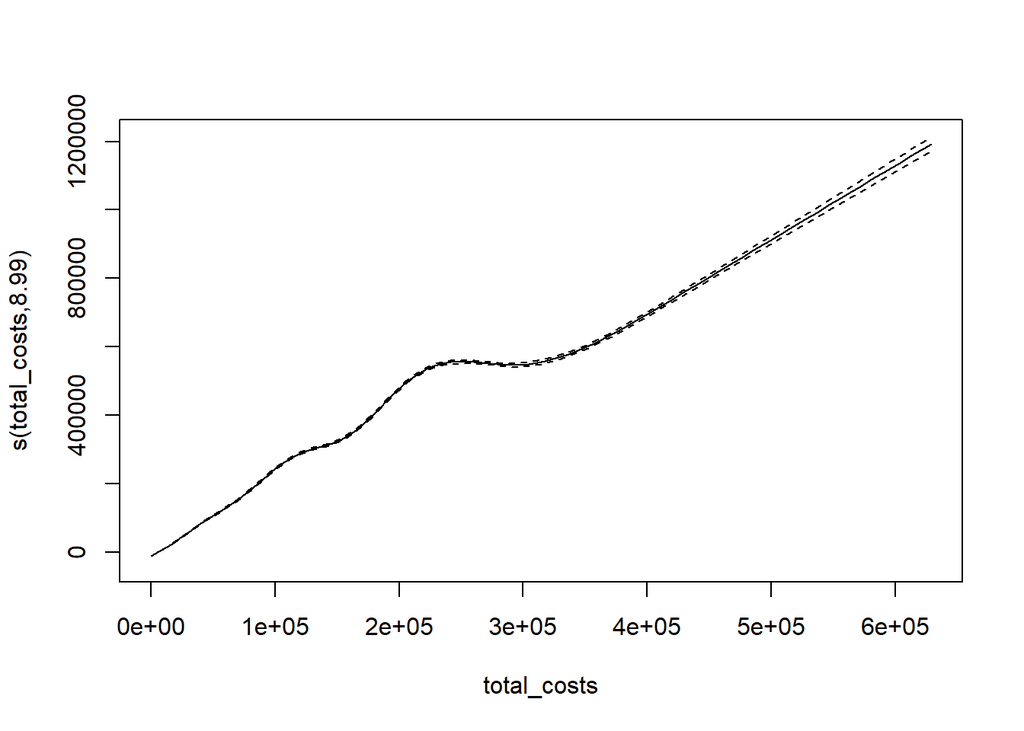

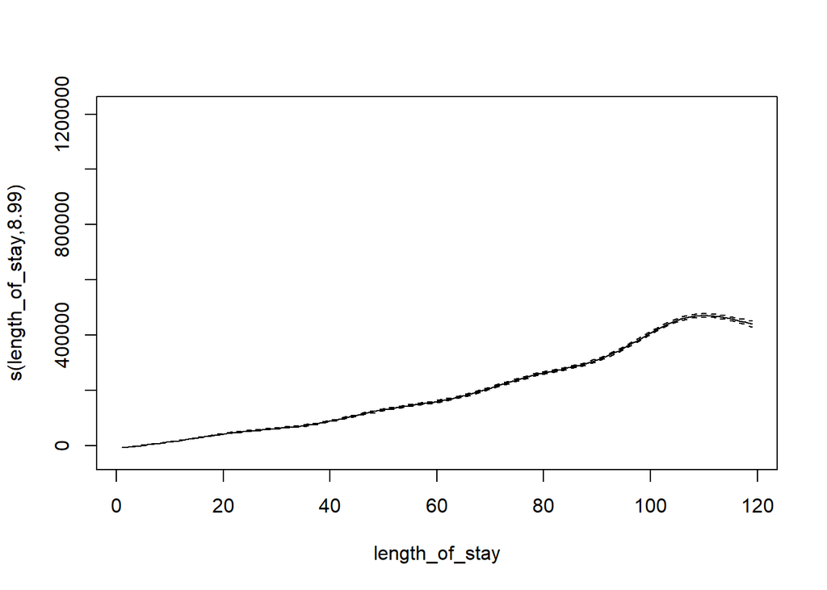

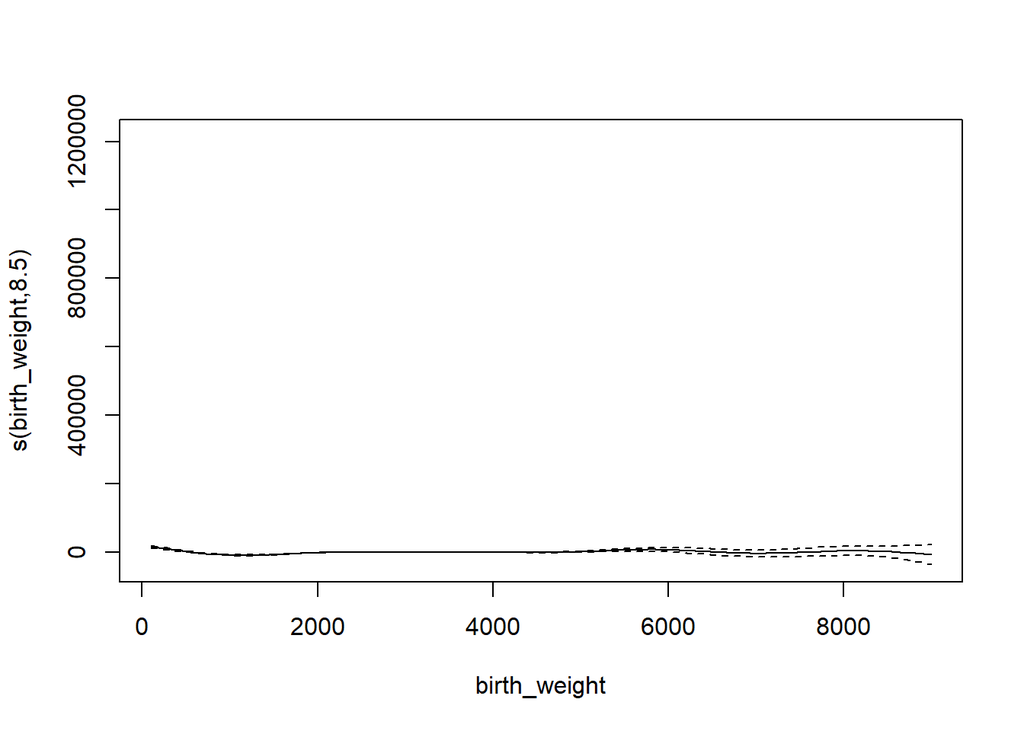

```r
gam.m <-gam(total_charges~s(total_costs)+s(length_of_stay)+s(birth_weight), data = trsf2)
plot(gam.m)
```

```r
gam.fit <-train(x, y,
                method = "gam",
                tuneGrid =data.frame(method = "GCV.Cp", select =c(TRUE,FALSE)),
                trControl = ctrl1)
```

```r
resamp <-resamples(list(lm = lm.fit2, PCR = pcr.fit2, lasso=lasso.fit, enet=enet.fit, gam=gam.fit))
summary(resamp)
```

```
##
## Call:
## summary.resamples(object = resamp)
##
## Models: lm, PCR, lasso, enet, gam
## Number of resamples: 5
##
## MAE
##           Min.  1st Qu.   Median     Mean  3rd Qu.     Max. NA's
## lm    7447.404 7459.158 7551.721 7563.356 7665.259 7693.241    0
## PCR   7443.093 7459.158 7551.721 7561.453 7659.574 7693.721    0
## lasso 7322.724 7328.926 7415.004 7435.997 7538.768 7574.565    0
## enet  7321.730 7327.762 7413.749 7434.856 7537.670 7573.370    0
## gam   6731.265 6750.699 6867.730 6852.467 6928.492 6984.151    0
##
## RMSE
##           Min.  1st Qu.   Median     Mean  3rd Qu.     Max. NA's
## lm    26237.20 26445.88 27359.29 27192.46 27492.45 28427.46    0
## PCR   26151.59 26445.88 27364.43 27173.47 27492.45 28413.02    0
## lasso 26168.07 26458.53 27370.91 27177.14 27485.20 28403.01    0
## enet  26167.84 26458.66 27371.04 27177.15 27485.30 28402.91    0
## gam   26226.86 26669.49 26727.94 27269.39 28358.77 28363.90    0
##
## Rsquared
##            Min.   1st Qu.    Median      Mean   3rd Qu.      Max. NA's
## lm    0.8293520 0.8306988 0.8348643 0.8347995 0.8389696 0.8401125    0
## PCR   0.8295272 0.8317493 0.8348643 0.8350327 0.8389099 0.8401125    0
## lasso 0.8296641 0.8314605 0.8349549 0.8349860 0.8388272 0.8400231    0
## enet  0.8296654 0.8314626 0.8349537 0.8349859 0.8388258 0.8400222    0
## gam   0.8129773 0.8296571 0.8325752 0.8338923 0.8423329 0.8519190    0
```

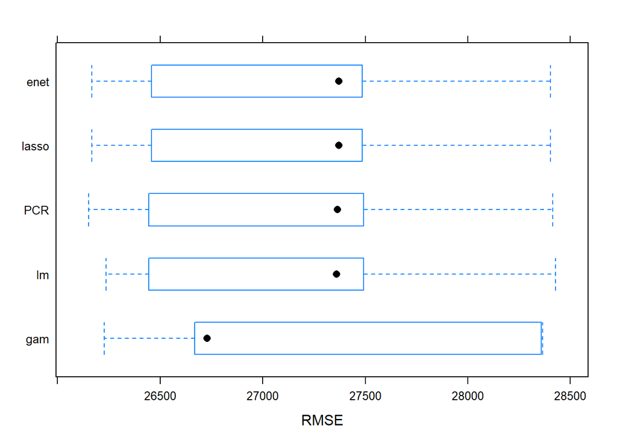

```r
bwplot((resamp), metric = "RMSE")
```

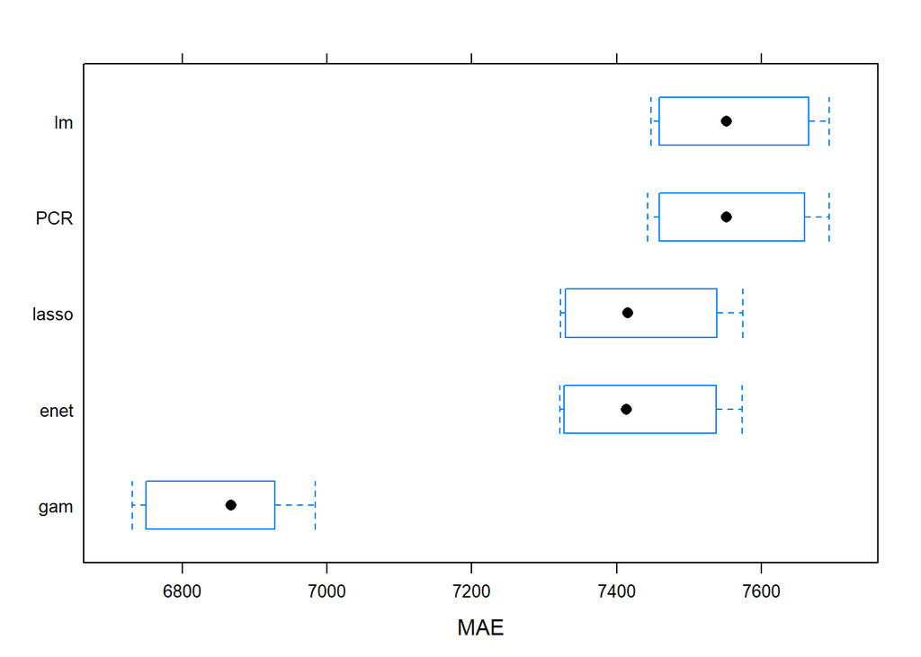

```r
bwplot((resamp), metric = "MAE")
```